# Climatic Trends and Agriculture Expansion on Declining Water Levels in Arid Aquifer, Iran

Luna Herschenfeld-Catalán

2023-12-14

# Problem

Groundwater supplies water resources for drinking water and irrigated agriculture for millions of people around the world. Groundwater levels are declining around the world. This is partly do to changing climatic trends, where declines in precipitation is leading to declines in recharge of groundwater storage in aquifers. Over the last couple of decades, agriculture production in many areas has also increased (James & Elfers, 2015). In arid regions, agriculture is mainly fed by groundwater since there is not enough surface water available, or it does not rain enough.

This analysis can help guide groundwater management strategy by shedding light on how different factors are contributing to the rapid decline, with the hope of developing effective management strategies to protect groundwater resources.

# Data

## Sources

GROUNDWATER LEVEL

Groundwater level depth data was provided by Scott Jasechko’s lab. Multiple measurements were taken from 1978-2018, with 2002-2003 data missing. I used the mean values each year to calculate the change in groundwater levels from one year to the next. - stored in `data` as `groundwater_time_series.xlsx`

ANNUAL PRECIPITATION

I focused on annual precipitation as a proxy for climatic trends in this analysis. This data was provided by CHELSA-EarthEnv (Karget et al. 2021). - Stored in `data` as `annual_precip.xlsx`

AGRICULTURE PRODUCTION

The summary statistics are stored in the `ag_density` folder: - `buffer_df.csv` contains the summary stats for the 6000m buffer around the groundwater well - `aq_df.csv` contains the summary stats for the raster clipped to the aquifer geometry

I clipped both data sets with a shapefile of the Qazvin Aquifer that I created in ArcGIS using a map from Mirhashemi & Mirzaei (2021) The image and the shapefile can be accessed in this project repository saved as `qazvin`. - The aquifer shapefile is stored in the `data` folder as `qazvin`

# Prepare the Data

### Load in the libraries

```r
# load libraries
library(foreign)
library(tidyverse)
library(here)
library(sf)
library(terra)
library(geodata)
library(modelr)
library(ggplot2)
library(lubridate) # for dates
library(sjPlot)
```

## Load in the data

### Depth to Groundwater Level Time Series

I wanted to compare the yearly change in groundwater level, precipitation, and agricultural production in the Qazvin plain. To to this I first had to clean the depth to groundwater data so that I could work with the yearly mean measurement. I accessed the year with `separate_wider_delim()` and then used the `group_by()` and `summarize()` functions to generate a yearly mean depth to groundwater. However, I was interested in the change, so I used a first difference estimator to calculate the change in groundwater depth each year.

```r
gw_level_total <- readxl::read_xlsx(here("data/groundwater_time_series.xlsx")) %>%
  select(Year, WaterLevel) %>% # select years
  separate_wider_delim(col = Year,
                       ".", # separate the months
                       names = c("Year", "Month")) %>%
  select(!Month) %>% # remove the decimal column
  mutate_at(vars(Year), as.numeric)


# these are the mean depth to groundwater level
gw_mean <- gw_level_total %>%
  group_by(Year) %>%
  summarize(mean = mean(WaterLevel)) %>%
  rename(year = Year)

# find the first difference
mean_2 = gw_mean$mean[1:38]
mean_2  <- c(0,mean_2 )
mean_2 <- data.frame(year = gw_mean$year,
                     mean_2 = mean_2)

gw_mean <-  gw_mean %>%
  left_join(mean_2)

gw_change <- gw_mean %>%
  mutate(change = as.numeric(mean_2) - (as.numeric(mean))) %>% # find the change
  slice(-1)

#------ Precipitation Data ------#

precip <- readxl::read_xlsx(here("data/annual_precip.xlsx")) %>%
  select(!StnID) # remove column
```

### Area Equipped for Irrigation Data

I also only wanted to use the AEI over the Qazvin Plain, so I used `crop()` to clip the AEI raster stack with the qazvin aquifer shapefile I created. Then I calculated summary statistics across each raster in the stack. I was then able to join the change in groundwater level data with the precipitation and irrigation data.

```r
# make bounding box
qazvin_aquifer <- st_read(here('data/qazvin/qazvin.shp'))
```

```r
qazvin_box <- data.frame(name = c("1", "2", "3", "4"),
                         long = c(49.31937729228426, 49.31937729228426, 51.12523623049739, 51.12523623049739),
                         lat = c(36.493217304744505, 35.52665079679184, 35.52665079679184, 36.493217304744505))

qazvin_box = st_polygon(list(
  cbind(
    qazvin_box$long[c(1, 2, 3, 4, 1)],
    qazvin_box$lat[c(1, 2, 3, 4, 1)]
  )
))

# list files for each band, including the full file path
filelist <- list.files(here("data/AEI_ASC/"), # say what folder to read the files in
                       full.names = TRUE)

# read in and store as a raster stack
asc_1900_2015 <- rast(filelist)

# need to set crs
qazvin_box <- st_sfc(qazvin_box,
                     crs = st_crs(asc_1900_2015))

irrigation_qazvin <- asc_1900_2015 %>%
  crop(., qazvin_box)

names(irrigation_qazvin) <- c("1900", "1910", "1920", "1930", "1940", "1950", "1960", "1970", "1980", "1985", "1990", "1995", "2000", "2005", "2010", "2015")

# transform shapefle to crs of irrigation map
qazvin_aquifer <- st_transform(qazvin_aquifer,
                               crs = st_crs(irrigation_qazvin))

ir_aq <- irrigation_qazvin %>%
  crop(., qazvin_aquifer)



ir_df <- as.data.frame(ir_aq) %>%
  pivot_longer(1:16,
               names_to = "year",
               values_to = "values") %>%
  mutate_at(vars(year), as.numeric)

# create summary dataframe with irrigation statistics
ir_summary <- ir_df %>%
  group_by(year) %>%
  mutate(ir_mean = mean(values, na.rm = TRUE),
         ir_sd = sd(values, na.rm = TRUE),
         ir_max = max(values, na.rm = TRUE),
         ir_median = median(values, na.rm = TRUE),
         ir_sum = sum(values, na.rm = TRUE)) %>%
  select(!values) %>%
  slice(16)
```

### Load in SAVI statistics for Buffered Area

```r
quartile_names <- c("min_b", "q1_b", "median_b", "q3_b", "max_b", "sum_b", "mean_b")


buffer_ag <- read_csv(here("data/ag_density/buffer_df.csv")) %>%
  rename("quartiles" = "...1") %>%
  replace("quartiles", quartile_names) %>%
  pivot_longer(col = 2:131,
               names_to = 'date',
               values_to = 'values') %>%
  separate_wider_delim(cols = 2,
                       delim = ">_", names = c("date", "type")) %>%
  separate(col = 2,
           into = "string",
           sep = "_02") %>%
  separate_wider_delim(cols = 2, delim = "165035_", names = c("left", "date")) %>%
  select(!left)

savi_date <- ymd(buffer_ag$date, format="%Y%m%d")
savi_date <- savi_date[-length(savi_date)]

buffer_ag <- buffer_ag %>%
  cbind(savi_date) %>%
  select(quartiles,
         date = savi_date,
         values,
         type) %>%
  filter(buffer_ag$quartiles != "min")

buffer_years <- buffer_ag %>%
  separate_wider_delim(cols = 2,
                       delim = "-05-",
                       names = c("year", "md")) %>%
  select(!md) %>%
  group_by(year, quartiles, type) %>%
  summarize(val = mean(values)) %>%
  mutate_at(vars(year), as.numeric) %>%
  pivot_wider(names_from = quartiles,
              values_from = val) %>%
  ungroup()

# store just the NDVI values
buffer_ndvi <- buffer_years %>%
  filter(type %in% "ndvi") %>%
  rename(qi_bn = "q1_b",
         median_bn = "median_b",
         q3_bn = "q3_b",
         max_bn = "max_b",
         sum_bn = "sum_b",
         mean_bn = "mean_b")

# store just the SAVI
buffer_savi <- buffer_years %>%
  filter(type %in% "savi") %>%
  rename(qi_bs = "q1_b",
         median_bs = "median_b",
         q3_bs = "q3_b",
         max_bs = "max_b",
         sum_bs = "sum_b",
         mean_bs = "mean_b")
```

### Load in SAVI statistics for Aquifer Area

```r
quartile_names <- c("min_a", "q1_a", "median_a", "q3_a", "max_a", "sum_a", "mean_a")


aquifer_ag <- read_csv(here("data/ag_density/aq_df.csv")) %>%
  rename("quartiles" = "...1") %>%
  replace("quartiles", quartile_names) %>%
  pivot_longer(col = 2:131,
               names_to = 'date',
               values_to = 'values') %>%
  separate_wider_delim(cols = 2,
                       delim = ">_", names = c("date", "type")) %>%
  separate(col = 2,
           into = "string",
           sep = "_02") %>%
  separate_wider_delim(cols = 2, delim = "165035_", names = c("left", "date")) %>%
  select(!left)

savi_date <- ymd(buffer_ag$date, format="%Y%m%d")
savi_date <- savi_date[-length(savi_date)]

aquifer_ag <- aquifer_ag %>%
  cbind(savi_date) %>%
  select(quartiles,
         date = savi_date,
         values,
         type) %>%
  filter(aquifer_ag$quartiles != "min")

aquifer_years <- aquifer_ag %>%
  separate_wider_delim(cols = 2,
                       delim = "-05-",
                       names = c("year", "md")) %>%
  select(!md) %>%
  group_by(year, quartiles, type) %>%
  summarize(val = mean(values)) %>%
  mutate_at(vars(year), as.numeric) %>%
  pivot_wider(names_from = quartiles,
              values_from = val) %>%
  ungroup()

aquifer_ndvi <- aquifer_years %>%
  filter(type %in% "ndvi") %>%
  rename(qi_an = "q1_a",
         median_an = "median_a",
         q3_an = "q3_a",
         max_an = "max_a",
         sum_an = "sum_a",
         mean_an = "mean_a")

aquifer_savi <- aquifer_years %>%
  filter(type %in% "savi") %>%
  rename(qi_as = "q1_a",
         median_as = "median_a",
         q3_as = "q3_a",
         max_as = "max_a",
         sum_as = "sum_a",
         mean_as = "mean_a")
```

### Dataframe with Combined Data

After reading in all of the data, I created a clean version using `left_join()` of the data related to the Qazvin Plain so that it was easy to work with.

```r
#------- All data Together ------#
qazvin_clean <- precip %>%
  left_join(gw_change, by = "year") %>%
  left_join(ir_summary, by = "year") %>%
  left_join(aquifer_ndvi, by = "year") %>%
  left_join(aquifer_savi, by = "year") %>%
  left_join(buffer_ndvi, by = "year") %>%
  left_join(buffer_savi, by = "year") %>%
  rename(gw_level = mean,
         annual_precip = total_annual_precip)
```

# Basic Analysis Approach

## Multiple Linear Regression with AEI mean

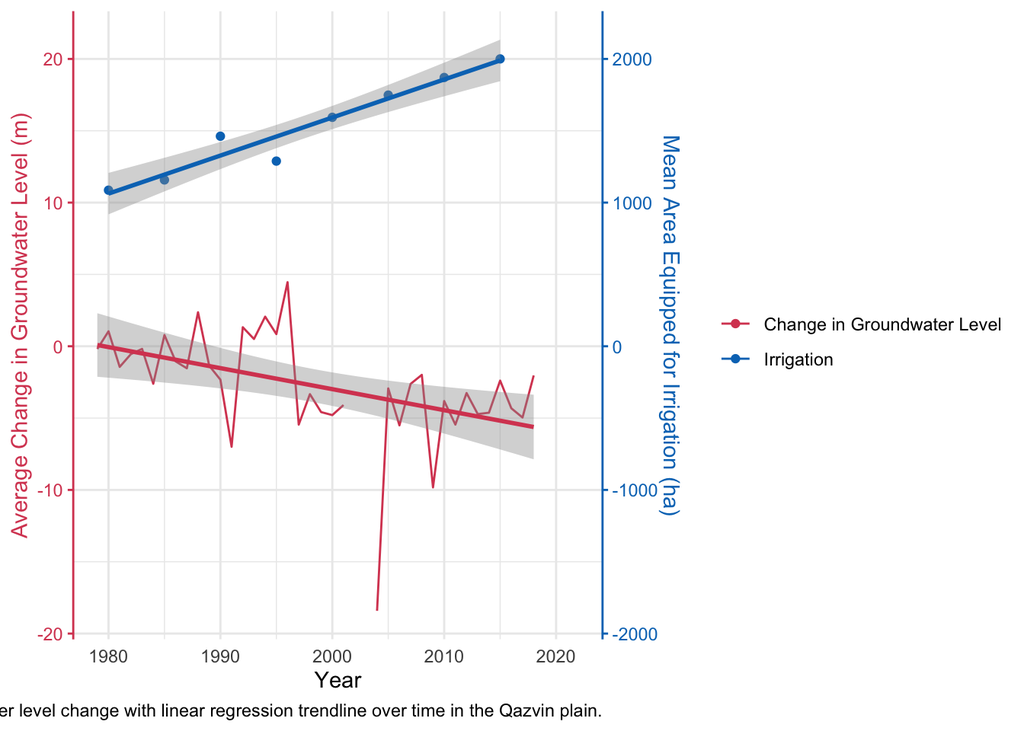

```r
scale = 100

ir_gw_plot <- ggplot(qazvin_clean, aes(x = year, y = change)) +
  geom_line(aes(color = "Change in Groundwater Level")) +
  geom_point(aes(y = ir_mean/scale,
                 color = "Irrigation")) +
  scale_y_continuous(sec.axis = sec_axis(~.*scale)) +
  stat_smooth(aes(y = change),method = "lm", formula = y ~ x, size = 1,
              color = "#D84860FF") +
  stat_smooth(aes(y = ir_mean/scale),method = "lm", formula = y ~ x, size = 1,
              color = "#0076C0FF") +
  labs(x = "Year",
       y = "Change in Groundwater Level",
       color = "",
       caption = "Fig.1 Plot showing AEI and groundwater level change with linear regression trendline over time in the Qazvin plain.") +
  scale_y_continuous( "Average Change in Groundwater Level (m)",
                      sec.axis = sec_axis(~ . * 100,
                                          name = "Mean Area Equipped for Irrigation (ha)")) +
  theme_minimal() +
  theme( axis.line.y.right = element_line(color = "#0076C0FF"),
         axis.ticks.y.right = element_line(color = "#0076C0FF"),
         axis.text.y.right = element_text(color = "#0076C0FF"),
         axis.title.y.right = element_text(color = "#0076C0FF"),
         axis.line.y.left = element_line(color = "#D84860FF"),
         axis.ticks.y.left = element_line(color = "#D84860FF"),
         axis.text.y.left = element_text(color = "#D84860FF"),
         axis.title.y.left  = element_text(color = "#D84860FF")) +
   scale_color_manual(values = c("#D84860FF", "#0076C0FF"))

ir_gw_plot
```

Run regression model:

```r
mod_ir_precip <- lm(change ~ ir_mean + annual_precip, data = qazvin_clean) %>%
  summary() %>%
  tab_model(title = "groundwater change ~ irrigation + annual precipitation")
```

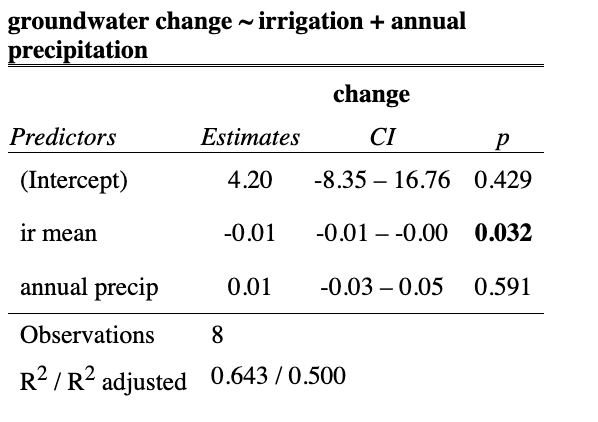

Table 1: Results of Multiple Linear Regression of Area Equipped for Irrigation and Precipitation on Groundwater Level Change

The result of the multiple linear regression model are in Table 1, and they indicate that for every 1 ha increase in AEI, there is a 0.01 m decrease in groundwater level. The effect of AEI has a p-value of 0.032, which is small enough that there is statistical significance of this analysis. However, the p-value for annual precipitation is 0.591, meaning that there can be no statistical significance taken from the role of precipitation on grondwater level change. This model had an R^2 value of 0.50 which means it explained 50% of the variation in groundwater level change.

Run regression model:

```r
mod_ir <- lm(change ~ ir_mean, data = qazvin_clean) %>%
  summary() %>%
  tab_model(title = "groundwater change ~ irrigation")
```

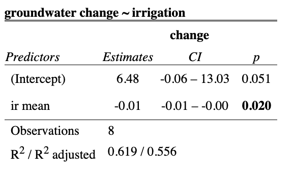

Table 2: Results of Simple Linear Regression of Area Equipped on Irrigation on Groundwater Level Change

Then I ran a simple linear regression model to see the effect of just AEI mean. The results in Table 2 show that the p-value is 0.02, which increases our confidence level that AEI mean is statistically significant. Here, the R^2 value has increased to 0.56, which means this model explains 56% of the variation in groundwater level change. Given the higher R^2 value, this model is more useful than the one that includes precipitation.

## Simple Linear Regression with median Soil Adjusted Vegetation Index (SAVI)

I was unhappy with the temporal resolution of the irrigation data, since it was an aggregate in 5-year chunks that was already accessing data samples. To have more confidence in my results, I calculated the SAVI from the area of a buffer around the well being used to to collect the groundwater level data, and across the aquifer in Python. Then I extracted summary statistics from each raster.

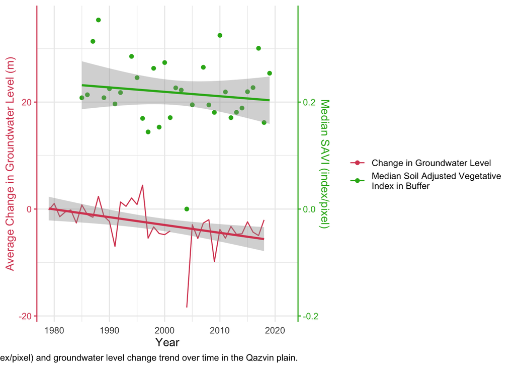

```r
savi_plot <- ggplot(qazvin_clean, aes(x = year, y = change)) +
  geom_line(aes(color = "Change in Groundwater Level")) +
  geom_point(aes(y = median_bs*scale,
                 color = "Median Soil Adjusted Vegetative \nIndex in Buffer")) +
  stat_smooth(aes(y = change),method = "lm", formula = y ~ x, size = 1,
              color = "#D84860FF") +
  stat_smooth(aes(y = median_bs*scale),method = "lm", formula = y ~ x, size = 1,
              color = "#2CB11BFF") +
  labs(x = "Year",
       y = "Change in Groundwater Level",
       color = "",
       caption = "Fig. XYZ Simple linear regression plot showing Median SAVI (index/pixel) and groundwater level change trend over time in the Qazvin plain.") +
  scale_y_continuous( "Average Change in Groundwater Level (m)",
                      sec.axis = sec_axis(~ . * .01,
                                          name = "Median SAVI (index/pixel)")) +
  theme_minimal() +
  theme( axis.line.y.right = element_line(color = "#2CB11BFF"),
         axis.ticks.y.right = element_line(color = "#2CB11BFF"),
         axis.text.y.right = element_text(color = "#2CB11BFF"),
         axis.title.y.right = element_text(color = "#2CB11BFF"),
         axis.line.y.left = element_line(color = "#D84860FF"),
         axis.ticks.y.left = element_line(color = "#D84860FF"),
         axis.text.y.left = element_text(color = "#D84860FF"),
         axis.title.y.left  = element_text(color = "#D84860FF")) +
   scale_color_manual(values = c("#D84860FF", "#2CB11BFF"))

savi_plot
```

```r
# these are correlated
mod_median <- lm(change ~ median_bs, data = qazvin_clean) %>%
  summary() %>%
  tab_model()
```

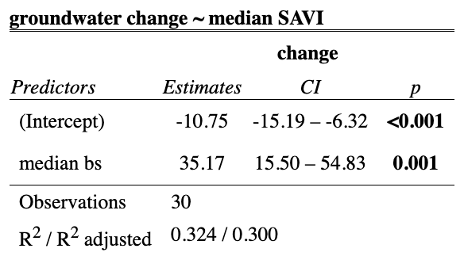

Table 3: Results of Simple Linear Regression of median Soil Adjusted Vegetation Index (SAVI) on Irrigation on Groundwater Level Change

HYPOTHESIS TESTING

Due to the statistical significance of the median soil adjusted vegetation index and the non-statistical significance of the annual precipitation, we fail to accept the null hypothesis.

*Null Hypothesis:* In the Qazvin Plain, there is no difference of the impact of annual precipitaion and agricultural production changes on groundwater level changes from 1984-2019.

*Alternative Hypothesis:* In the Qazvin Plain, there is a difference of the impact of annual precipitation and agricultural production on groundwater level changes from 1984-2019.

CONFIDENCE INTERVAL

I calculated a confidence interval and am 95% confident that the true change in groundwater level for every 0.1 increase in the median SAVI, is within the range of 1.6 and 5.5m.

# Conclusions and Future Analysis

This analysis showed that agricultural production (proxied by **area equipped for irrigation** and **soil adjusted vegetative index**) had a greater impact on groundlevel changes in the Qazvin Plain aquifer than precipitation.

#### Data Availability

Data can be accessed from the sources described in the Data Sources section of this blog. The grondwater level time series data is not publicly available.

# References

1. Babaee, S., Mousavi, Z., Masoumi, Z., Malekshah, A. H., Roostaei, M., & Aflaki, M. (2020). Land subsidence from interferometric SAR and groundwater patterns in the Qazvin plain, Iran. International Journal of Remote Sensing, 41(12), 4780-4798.
2. *FAO empowers farmers to improve agriculture water productivity in Iran*. En.irna.ir. (n.d.). https://en.irna.ir/news/84184519/FAO-empowers-farmers-to-improve-agriculture-water-productivity
3. James, I., & Elfers, S. (2015). *Pumped Dry: The global crisis of vanishing groundwater*. Pulitzer Center. https://pulitzercenter.org/projects/pumped-dry-global-crisis-vanishing-groundwater.
4. Karger, D.N., Wilson, A.M., Mahony, C. *et al.* (2021). Global daily 1 km land surface precipitation based on cloud cover-informed downscaling. *Sci Data* **8**, 307. https://doi.org/10.1038/s41597-021-01084-6
5. Mehta, P., Siebert, S., Kummu, M., Deng, Q., Ali, T., Marston, L., Xie, W., & Davis, K. (2023). Global Area Equipped for Irrigation Dataset 1900-2015 (Version 3)
   $$Data set$$
   . Zenodo. https://doi.org/10.5281/zenodo.7809342
6. Mirhashemi, S. H., & Mirzaei, F. (2021). Extracting association rules from changes in aquifer drawdown in irrigation areas of Qazvin plain, Iran. Groundwater for Sustainable Development, 12, 100495.